# course_project

### Loading packages and reading the data

```r
library(tidyverse) # for data analysis and visualization

library(caret) # for machine learning models

library(knitr) # for creating tables

dat<-read.csv("D:/R/coursera/machinelearning/pml-training.csv")
```

### Exploring the train data

```r
glimpse(dat)
```

```
## Rows: 19,622
## Columns: 160
## $ X                        <int> 1, 2, 3, 4, 5, 6, 7, 8, 9, 10, 11, 12, 13, 14~
## $ user_name                <chr> "carlitos", "carlitos", "carlitos", "carlitos~
## $ raw_timestamp_part_1     <int> 1323084231, 1323084231, 1323084231, 132308423~
## $ raw_timestamp_part_2     <int> 788290, 808298, 820366, 120339, 196328, 30427~
## $ cvtd_timestamp           <chr> "05/12/2011 11:23", "05/12/2011 11:23", "05/1~
## $ new_window               <chr> "no", "no", "no", "no", "no", "no", "no", "no~
## $ num_window               <int> 11, 11, 11, 12, 12, 12, 12, 12, 12, 12, 12, 1~
## $ roll_belt                <dbl> 1.41, 1.41, 1.42, 1.48, 1.48, 1.45, 1.42, 1.4~
## $ pitch_belt               <dbl> 8.07, 8.07, 8.07, 8.05, 8.07, 8.06, 8.09, 8.1~
## $ yaw_belt                 <dbl> -94.4, -94.4, -94.4, -94.4, -94.4, -94.4, -94~
## $ total_accel_belt         <int> 3, 3, 3, 3, 3, 3, 3, 3, 3, 3, 3, 3, 3, 3, 3, ~
## $ kurtosis_roll_belt       <chr> "", "", "", "", "", "", "", "", "", "", "", "~
## $ kurtosis_picth_belt      <chr> "", "", "", "", "", "", "", "", "", "", "", "~
```

[output cut: 147 more lines]

```r
head(dat)
```

```
##   X user_name raw_timestamp_part_1 raw_timestamp_part_2   cvtd_timestamp
## 1 1  carlitos           1323084231               788290 05/12/2011 11:23
## 2 2  carlitos           1323084231               808298 05/12/2011 11:23
## 3 3  carlitos           1323084231               820366 05/12/2011 11:23
## 4 4  carlitos           1323084232               120339 05/12/2011 11:23
## 5 5  carlitos           1323084232               196328 05/12/2011 11:23
## 6 6  carlitos           1323084232               304277 05/12/2011 11:23
##   new_window num_window roll_belt pitch_belt yaw_belt total_accel_belt
## 1         no         11      1.41       8.07    -94.4                3
## 2         no         11      1.41       8.07    -94.4                3
## 3         no         11      1.42       8.07    -94.4                3
## 4         no         12      1.48       8.05    -94.4                3
## 5         no         12      1.48       8.07    -94.4                3
## 6         no         12      1.45       8.06    -94.4                3
##   kurtosis_roll_belt kurtosis_picth_belt kurtosis_yaw_belt skewness_roll_belt
```

[output cut: 251 more lines]

```r
tail(dat)
```

```
##           X user_name raw_timestamp_part_1 raw_timestamp_part_2
## 19617 19617    adelmo           1322832937               588324
## 19618 19618    adelmo           1322832937               588376
## 19619 19619    adelmo           1322832937               596287
## 19620 19620    adelmo           1322832937               636283
## 19621 19621    adelmo           1322832937               964299
## 19622 19622    adelmo           1322832937               972293
##         cvtd_timestamp new_window num_window roll_belt pitch_belt yaw_belt
## 19617 02/12/2011 13:35         no        864       148      -34.7      129
## 19618 02/12/2011 13:35         no        864       147      -34.8      129
## 19619 02/12/2011 13:35         no        864       145      -35.3      130
## 19620 02/12/2011 13:35         no        864       145      -35.5      130
## 19621 02/12/2011 13:35         no        864       143      -35.9      131
## 19622 02/12/2011 13:35        yes        864       143      -36.0      132
##       total_accel_belt kurtosis_roll_belt kurtosis_picth_belt kurtosis_yaw_belt
```

[output cut: 265 more lines]

The data is composed of 19,622 rows and 160 columns.

Some columns are numeric and some are character or categorical.

### Character columns

```r
dat_cat<-dat %>% select_if(is.character)

dim(dat_cat)
```

```
## [1] 19622    37
```

```r
sapply(dat_cat,class)
```

```
##               user_name          cvtd_timestamp              new_window
##             "character"             "character"             "character"
##      kurtosis_roll_belt     kurtosis_picth_belt       kurtosis_yaw_belt
##             "character"             "character"             "character"
##      skewness_roll_belt    skewness_roll_belt.1       skewness_yaw_belt
##             "character"             "character"             "character"
##            max_yaw_belt            min_yaw_belt      amplitude_yaw_belt
##             "character"             "character"             "character"
##       kurtosis_roll_arm      kurtosis_picth_arm        kurtosis_yaw_arm
##             "character"             "character"             "character"
##       skewness_roll_arm      skewness_pitch_arm        skewness_yaw_arm
##             "character"             "character"             "character"
##  kurtosis_roll_dumbbell kurtosis_picth_dumbbell   kurtosis_yaw_dumbbell
##             "character"             "character"             "character"
##  skewness_roll_dumbbell skewness_pitch_dumbbell   skewness_yaw_dumbbell
##             "character"             "character"             "character"
##        max_yaw_dumbbell        min_yaw_dumbbell  amplitude_yaw_dumbbell
##             "character"             "character"             "character"
##   kurtosis_roll_forearm  kurtosis_picth_forearm    kurtosis_yaw_forearm
##             "character"             "character"             "character"
##   skewness_roll_forearm  skewness_pitch_forearm    skewness_yaw_forearm
##             "character"             "character"             "character"
##         max_yaw_forearm         min_yaw_forearm   amplitude_yaw_forearm
##             "character"             "character"             "character"
##                  classe
##             "character"
```

```r
x<-nearZeroVar(dat_cat, names = T)

x
```

```
##  [1] "new_window"              "kurtosis_roll_belt"
##  [3] "kurtosis_picth_belt"     "kurtosis_yaw_belt"
##  [5] "skewness_roll_belt"      "skewness_roll_belt.1"
##  [7] "skewness_yaw_belt"       "max_yaw_belt"
##  [9] "min_yaw_belt"            "amplitude_yaw_belt"
## [11] "kurtosis_roll_arm"       "kurtosis_picth_arm"
## [13] "kurtosis_yaw_arm"        "skewness_roll_arm"
## [15] "skewness_pitch_arm"      "skewness_yaw_arm"
## [17] "kurtosis_roll_dumbbell"  "kurtosis_picth_dumbbell"
## [19] "kurtosis_yaw_dumbbell"   "skewness_roll_dumbbell"
## [21] "skewness_pitch_dumbbell" "skewness_yaw_dumbbell"
## [23] "max_yaw_dumbbell"        "min_yaw_dumbbell"
## [25] "amplitude_yaw_dumbbell"  "kurtosis_roll_forearm"
## [27] "kurtosis_picth_forearm"  "kurtosis_yaw_forearm"
## [29] "skewness_roll_forearm"   "skewness_pitch_forearm"
## [31] "skewness_yaw_forearm"    "max_yaw_forearm"
## [33] "min_yaw_forearm"         "amplitude_yaw_forearm"
```

```r
dat_cat2<-dat_cat %>% select(-all_of(x))

head(dat_cat2)
```

```
##   user_name   cvtd_timestamp classe
## 1  carlitos 05/12/2011 11:23      A
## 2  carlitos 05/12/2011 11:23      A
## 3  carlitos 05/12/2011 11:23      A
## 4  carlitos 05/12/2011 11:23      A
## 5  carlitos 05/12/2011 11:23      A
## 6  carlitos 05/12/2011 11:23      A
```

There are 37 categorical columns. After removing near zero variance columns, only 3 columns remain, of which, the classe column is our outcome and the other 2 columns are not important as predictors, the user name and the time stamp.

### Numeric columns

```r
dat_num<-dat %>% select(-all_of(names(dat_cat)))

dim(dat_num)
```

```
## [1] 19622   123
```

```r
sapply(dat_num,class)
```

```
##                        X     raw_timestamp_part_1     raw_timestamp_part_2
##                "integer"                "integer"                "integer"
##               num_window                roll_belt               pitch_belt
##                "integer"                "numeric"                "numeric"
##                 yaw_belt         total_accel_belt            max_roll_belt
##                "numeric"                "integer"                "numeric"
##           max_picth_belt            min_roll_belt           min_pitch_belt
##                "integer"                "numeric"                "integer"
##      amplitude_roll_belt     amplitude_pitch_belt     var_total_accel_belt
##                "numeric"                "integer"                "numeric"
##            avg_roll_belt         stddev_roll_belt            var_roll_belt
##                "numeric"                "numeric"                "numeric"
##           avg_pitch_belt        stddev_pitch_belt           var_pitch_belt
##                "numeric"                "numeric"                "numeric"
##             avg_yaw_belt          stddev_yaw_belt             var_yaw_belt
##                "numeric"                "numeric"                "numeric"
##             gyros_belt_x             gyros_belt_y             gyros_belt_z
##                "numeric"                "numeric"                "numeric"
##             accel_belt_x             accel_belt_y             accel_belt_z
##                "integer"                "integer"                "integer"
##            magnet_belt_x            magnet_belt_y            magnet_belt_z
##                "integer"                "integer"                "integer"
##                 roll_arm                pitch_arm                  yaw_arm
##                "numeric"                "numeric"                "numeric"
##          total_accel_arm            var_accel_arm             avg_roll_arm
##                "integer"                "numeric"                "numeric"
##          stddev_roll_arm             var_roll_arm            avg_pitch_arm
##                "numeric"                "numeric"                "numeric"
##         stddev_pitch_arm            var_pitch_arm              avg_yaw_arm
##                "numeric"                "numeric"                "numeric"
##           stddev_yaw_arm              var_yaw_arm              gyros_arm_x
##                "numeric"                "numeric"                "numeric"
##              gyros_arm_y              gyros_arm_z              accel_arm_x
##                "numeric"                "numeric"                "integer"
##              accel_arm_y              accel_arm_z             magnet_arm_x
##                "integer"                "integer"                "integer"
##             magnet_arm_y             magnet_arm_z             max_roll_arm
##                "integer"                "integer"                "numeric"
##            max_picth_arm              max_yaw_arm             min_roll_arm
##                "numeric"                "integer"                "numeric"
```

[output cut: 27 more lines]

```
##                "numeric"                "numeric"                "numeric"
##  amplitude_pitch_forearm      total_accel_forearm        var_accel_forearm
##                "numeric"                "integer"                "numeric"
##         avg_roll_forearm      stddev_roll_forearm         var_roll_forearm
##                "numeric"                "numeric"                "numeric"
##        avg_pitch_forearm     stddev_pitch_forearm        var_pitch_forearm
##                "numeric"                "numeric"                "numeric"
##          avg_yaw_forearm       stddev_yaw_forearm          var_yaw_forearm
##                "numeric"                "numeric"                "numeric"
##          gyros_forearm_x          gyros_forearm_y          gyros_forearm_z
##                "numeric"                "numeric"                "numeric"
##          accel_forearm_x          accel_forearm_y          accel_forearm_z
##                "integer"                "integer"                "integer"
##         magnet_forearm_x         magnet_forearm_y         magnet_forearm_z
##                "integer"                "numeric"                "numeric"
```

```r
x<-nearZeroVar(dat_num, names = T)

x
```

```
##  [1] "avg_roll_arm"           "stddev_roll_arm"        "var_roll_arm"
##  [4] "avg_pitch_arm"          "stddev_pitch_arm"       "var_pitch_arm"
##  [7] "avg_yaw_arm"            "stddev_yaw_arm"         "var_yaw_arm"
## [10] "max_roll_arm"           "min_roll_arm"           "min_pitch_arm"
## [13] "amplitude_roll_arm"     "amplitude_pitch_arm"    "max_roll_forearm"
## [16] "min_roll_forearm"       "amplitude_roll_forearm" "avg_roll_forearm"
## [19] "stddev_roll_forearm"    "var_roll_forearm"       "avg_pitch_forearm"
## [22] "stddev_pitch_forearm"   "var_pitch_forearm"      "avg_yaw_forearm"
## [25] "stddev_yaw_forearm"     "var_yaw_forearm"
```

```r
dat_num2<-dat_num %>% select(-all_of(x))

head(dat_num2)
```

```
##   X raw_timestamp_part_1 raw_timestamp_part_2 num_window roll_belt pitch_belt
## 1 1           1323084231               788290         11      1.41       8.07
## 2 2           1323084231               808298         11      1.41       8.07
## 3 3           1323084231               820366         11      1.42       8.07
## 4 4           1323084232               120339         12      1.48       8.05
## 5 5           1323084232               196328         12      1.48       8.07
## 6 6           1323084232               304277         12      1.45       8.06
##   yaw_belt total_accel_belt max_roll_belt max_picth_belt min_roll_belt
## 1    -94.4                3            NA             NA            NA
## 2    -94.4                3            NA             NA            NA
## 3    -94.4                3            NA             NA            NA
## 4    -94.4                3            NA             NA            NA
## 5    -94.4                3            NA             NA            NA
## 6    -94.4                3            NA             NA            NA
##   min_pitch_belt amplitude_roll_belt amplitude_pitch_belt var_total_accel_belt
```

[output cut: 139 more lines]

```r
dat_num3<-dat_num2 %>% select(-1)

head(dat_num3)
```

```
##   raw_timestamp_part_1 raw_timestamp_part_2 num_window roll_belt pitch_belt
## 1           1323084231               788290         11      1.41       8.07
## 2           1323084231               808298         11      1.41       8.07
## 3           1323084231               820366         11      1.42       8.07
## 4           1323084232               120339         12      1.48       8.05
## 5           1323084232               196328         12      1.48       8.07
## 6           1323084232               304277         12      1.45       8.06
##   yaw_belt total_accel_belt max_roll_belt max_picth_belt min_roll_belt
## 1    -94.4                3            NA             NA            NA
## 2    -94.4                3            NA             NA            NA
## 3    -94.4                3            NA             NA            NA
## 4    -94.4                3            NA             NA            NA
## 5    -94.4                3            NA             NA            NA
## 6    -94.4                3            NA             NA            NA
##   min_pitch_belt amplitude_roll_belt amplitude_pitch_belt var_total_accel_belt
```

[output cut: 139 more lines]

There are 123 numerical columns. After removing near zero variance columns, only 97 columns remain, of which the X or serial number is not an important predictor so we removed it.

The remaining numerical columns are 96 only.

### Combine categorical (classe or outcome) and numerical columns

```r
dat_full<-bind_cols(classe = dat_cat2[,3], dat_num3)

head(dat_full)
```

```
##   classe raw_timestamp_part_1 raw_timestamp_part_2 num_window roll_belt
## 1      A           1323084231               788290         11      1.41
## 2      A           1323084231               808298         11      1.41
## 3      A           1323084231               820366         11      1.42
## 4      A           1323084232               120339         12      1.48
## 5      A           1323084232               196328         12      1.48
## 6      A           1323084232               304277         12      1.45
##   pitch_belt yaw_belt total_accel_belt max_roll_belt max_picth_belt
## 1       8.07    -94.4                3            NA             NA
## 2       8.07    -94.4                3            NA             NA
## 3       8.07    -94.4                3            NA             NA
## 4       8.05    -94.4                3            NA             NA
## 5       8.07    -94.4                3            NA             NA
## 6       8.06    -94.4                3            NA             NA
##   min_roll_belt min_pitch_belt amplitude_roll_belt amplitude_pitch_belt
```

[output cut: 139 more lines]

```r
dim(dat_full)
```

```
## [1] 19622    97
```

Now, the data is composed of 1 outcome column (classe) and 96 numerical predictors.

### Select important columns by doing one-way ANOVA

```r
# gather all columns except the classe column

dat_full2<-dat_full %>%

  tidyr::gather(key = "variable",value = "value", 2:97)

head(dat_full2)
```

```
##   classe             variable      value
## 1      A raw_timestamp_part_1 1323084231
## 2      A raw_timestamp_part_1 1323084231
## 3      A raw_timestamp_part_1 1323084231
## 4      A raw_timestamp_part_1 1323084232
## 5      A raw_timestamp_part_1 1323084232
## 6      A raw_timestamp_part_1 1323084232
```

```r
dim(dat_full2)
```

```
## [1] 1883712       3
```

```r
# do ANOVA and filter for significant variables

library(rstatix)

dat_res<-dat_full2 %>% group_by(variable) %>%

    anova_test(value ~ classe) %>% dplyr::filter(p<0.05)

dim(dat_res)
```

```
## [1] 77  8
```

```r
dat_res %>% kable(align = "c", digits = 2)
```

| variable | Effect | DFn | DFd | F | p | p<.05 | ges |
| --- | --- | --- | --- | --- | --- | --- | --- |
| accel_arm_x | classe | 4 | 19617 | 461.87 | 0.00 | * | 0.09 |
| accel_arm_y | classe | 4 | 19617 | 57.78 | 0.00 | * | 0.01 |
| accel_arm_z | classe | 4 | 19617 | 74.02 | 0.00 | * | 0.01 |
| accel_belt_x | classe | 4 | 19617 | 11.76 | 0.00 | * | 0.00 |
| accel_belt_y | classe | 4 | 19617 | 9.11 | 0.00 | * | 0.00 |
| accel_belt_z | classe | 4 | 19617 | 46.43 | 0.00 | * | 0.01 |
| accel_dumbbell_x | classe | 4 | 19617 | 393.67 | 0.00 | * | 0.07 |
| accel_dumbbell_y | classe | 4 | 19617 | 108.44 | 0.00 | * | 0.02 |
| accel_dumbbell_z | classe | 4 | 19617 | 110.75 | 0.00 | * | 0.02 |
| accel_forearm_x | classe | 4 | 19617 | 412.79 | 0.00 | * | 0.08 |
| accel_forearm_y | classe | 4 | 19617 | 79.62 | 0.00 | * | 0.02 |
| accel_forearm_z | classe | 4 | 19617 | 9.23 | 0.00 | * | 0.00 |
| amplitude_pitch_belt | classe | 4 | 401 | 68.69 | 0.00 | * | 0.41 |
| amplitude_pitch_dumbbell | classe | 4 | 401 | 3.35 | 0.01 | * | 0.03 |
| amplitude_pitch_forearm | classe | 4 | 401 | 7.80 | 0.00 | * | 0.07 |
| amplitude_roll_dumbbell | classe | 4 | 401 | 5.04 | 0.00 | * | 0.05 |
| amplitude_yaw_arm | classe | 4 | 401 | 17.77 | 0.00 | * | 0.15 |
| avg_pitch_dumbbell | classe | 4 | 401 | 11.11 | 0.00 | * | 0.10 |
| avg_roll_dumbbell | classe | 4 | 401 | 14.45 | 0.00 | * | 0.13 |
| gyros_arm_y | classe | 4 | 19617 | 4.30 | 0.00 | * | 0.00 |
| gyros_belt_x | classe | 4 | 19617 | 8.15 | 0.00 | * | 0.00 |
| gyros_belt_y | classe | 4 | 19617 | 3.25 | 0.01 | * | 0.00 |
| gyros_belt_z | classe | 4 | 19617 | 3.11 | 0.01 | * | 0.00 |
| gyros_dumbbell_y | classe | 4 | 19617 | 18.16 | 0.00 | * | 0.00 |
| gyros_forearm_x | classe | 4 | 19617 | 9.40 | 0.00 | * | 0.00 |
| magnet_arm_x | classe | 4 | 19617 | 659.79 | 0.00 | * | 0.12 |
| magnet_arm_y | classe | 4 | 19617 | 485.39 | 0.00 | * | 0.09 |
| magnet_arm_z | classe | 4 | 19617 | 371.80 | 0.00 | * | 0.07 |
| magnet_belt_x | classe | 4 | 19617 | 34.93 | 0.00 | * | 0.01 |
| magnet_belt_y | classe | 4 | 19617 | 679.40 | 0.00 | * | 0.12 |
| magnet_belt_z | classe | 4 | 19617 | 301.69 | 0.00 | * | 0.06 |
| magnet_dumbbell_x | classe | 4 | 19617 | 122.19 | 0.00 | * | 0.02 |
| magnet_dumbbell_y | classe | 4 | 19617 | 53.17 | 0.00 | * | 0.01 |
| magnet_dumbbell_z | classe | 4 | 19617 | 141.39 | 0.00 | * | 0.03 |
| magnet_forearm_x | classe | 4 | 19617 | 320.23 | 0.00 | * | 0.06 |
| magnet_forearm_y | classe | 4 | 19617 | 187.54 | 0.00 | * | 0.04 |
| magnet_forearm_z | classe | 4 | 19617 | 49.71 | 0.00 | * | 0.01 |
| max_picth_arm | classe | 4 | 401 | 3.63 | 0.01 | * | 0.04 |
| max_picth_belt | classe | 4 | 401 | 5.56 | 0.00 | * | 0.05 |
| max_picth_forearm | classe | 4 | 401 | 2.96 | 0.02 | * | 0.03 |
| max_roll_dumbbell | classe | 4 | 401 | 9.75 | 0.00 | * | 0.09 |
| max_yaw_arm | classe | 4 | 401 | 4.24 | 0.00 | * | 0.04 |
| min_pitch_forearm | classe | 4 | 401 | 5.69 | 0.00 | * | 0.05 |
| min_roll_dumbbell | classe | 4 | 401 | 3.93 | 0.00 | * | 0.04 |
| min_yaw_arm | classe | 4 | 401 | 13.02 | 0.00 | * | 0.12 |
| num_window | classe | 4 | 19617 | 223.42 | 0.00 | * | 0.04 |
| pitch_arm | classe | 4 | 19617 | 204.15 | 0.00 | * | 0.04 |
| pitch_belt | classe | 4 | 19617 | 7.10 | 0.00 | * | 0.00 |
| pitch_dumbbell | classe | 4 | 19617 | 412.35 | 0.00 | * | 0.08 |
| pitch_forearm | classe | 4 | 19617 | 1120.39 | 0.00 | * | 0.19 |
| raw_timestamp_part_1 | classe | 4 | 19617 | 11.59 | 0.00 | * | 0.00 |
| roll_arm | classe | 4 | 19617 | 142.06 | 0.00 | * | 0.03 |
| roll_belt | classe | 4 | 19617 | 34.08 | 0.00 | * | 0.01 |
| roll_dumbbell | classe | 4 | 19617 | 423.07 | 0.00 | * | 0.08 |
| roll_forearm | classe | 4 | 19617 | 82.79 | 0.00 | * | 0.02 |
| stddev_pitch_belt | classe | 4 | 401 | 45.24 | 0.00 | * | 0.31 |
| stddev_pitch_dumbbell | classe | 4 | 401 | 7.35 | 0.00 | * | 0.07 |
| stddev_roll_belt | classe | 4 | 401 | 56.50 | 0.00 | * | 0.36 |
| stddev_roll_dumbbell | classe | 4 | 401 | 7.61 | 0.00 | * | 0.07 |
| stddev_yaw_dumbbell | classe | 4 | 401 | 3.50 | 0.01 | * | 0.03 |
| total_accel_arm | classe | 4 | 19617 | 106.12 | 0.00 | * | 0.02 |
| total_accel_belt | classe | 4 | 19617 | 38.35 | 0.00 | * | 0.01 |
| total_accel_dumbbell | classe | 4 | 19617 | 68.95 | 0.00 | * | 0.01 |
| total_accel_forearm | classe | 4 | 19617 | 149.78 | 0.00 | * | 0.03 |
| var_accel_arm | classe | 4 | 401 | 11.04 | 0.00 | * | 0.10 |
| var_accel_dumbbell | classe | 4 | 401 | 3.98 | 0.00 | * | 0.04 |
| var_accel_forearm | classe | 4 | 401 | 9.86 | 0.00 | * | 0.09 |
| var_pitch_belt | classe | 4 | 401 | 28.95 | 0.00 | * | 0.22 |
| var_pitch_dumbbell | classe | 4 | 401 | 3.96 | 0.00 | * | 0.04 |
| var_roll_belt | classe | 4 | 401 | 23.59 | 0.00 | * | 0.19 |
| var_roll_dumbbell | classe | 4 | 401 | 6.49 | 0.00 | * | 0.06 |
| var_total_accel_belt | classe | 4 | 401 | 35.41 | 0.00 | * | 0.26 |
| var_yaw_dumbbell | classe | 4 | 401 | 2.49 | 0.04 | * | 0.02 |
| yaw_arm | classe | 4 | 19617 | 57.16 | 0.00 | * | 0.01 |
| yaw_belt | classe | 4 | 19617 | 9.22 | 0.00 | * | 0.00 |
| yaw_dumbbell | classe | 4 | 19617 | 65.69 | 0.00 | * | 0.01 |
| yaw_forearm | classe | 4 | 19617 | 60.21 | 0.00 | * | 0.01 |

```r
# select these important columns from the original data

dat_full3<-dat_full %>% dplyr::select(all_of(dat_res$variable), classe)


dim(dat_full3)
```

```
## [1] 19622    78
```

There are 77 important numerical columns according to ANOVA test.

Now, the data is composed of 1 outcome column (classe) and 77 numerical predictors.

### Remove columns with missing values

```r
library(naniar) # for seeing missing data

# filter for columns with no missing values

names<-miss_var_summary(dat_full3) %>% dplyr::filter(n_miss==0)

head(names)
```

```
## # A tibble: 6 x 3
##   variable     n_miss pct_miss
##   <chr>         <int>    <dbl>
## 1 accel_arm_x       0        0
## 2 accel_arm_y       0        0
## 3 accel_arm_z       0        0
## 4 accel_belt_x      0        0
## 5 accel_belt_y      0        0
## 6 accel_belt_z      0        0
```

```r
# select the columns with no missing values

dat_full4<-dat_full3 %>% dplyr::select(all_of(names$variable))

dim(dat_full4)
```

```
## [1] 19622    49
```

```r
head(dat_full4)
```

```
##   accel_arm_x accel_arm_y accel_arm_z accel_belt_x accel_belt_y accel_belt_z
## 1        -288         109        -123          -21            4           22
## 2        -290         110        -125          -22            4           22
## 3        -289         110        -126          -20            5           23
## 4        -289         111        -123          -22            3           21
## 5        -289         111        -123          -21            2           24
## 6        -289         111        -122          -21            4           21
##   accel_dumbbell_x accel_dumbbell_y accel_dumbbell_z accel_forearm_x
## 1             -234               47             -271             192
## 2             -233               47             -269             192
## 3             -232               46             -270             196
## 4             -232               48             -269             189
## 5             -233               48             -270             189
## 6             -234               48             -269             193
##   accel_forearm_y accel_forearm_z gyros_arm_y gyros_belt_x gyros_belt_y
```

[output cut: 55 more lines]

Now, the data is composed of 1 outcome column (classe) and 48 numerical predictors.

### Summary statistics of the numerical columns by the outcome

```r
library(knitr)

dat_full4 %>% dplyr::group_by(classe) %>%

  get_summary_stats(type = "common") %>% arrange(variable) %>%

  kable(align = "c", digits = 2)
```

| classe | variable | n | min | max | median | iqr | mean | sd | se | ci |
| --- | --- | --- | --- | --- | --- | --- | --- | --- | --- | --- |
| A | accel_arm_x | 5580 | -3.22000e+02 | 434.00 | -222.00 | 292.25 | -132.16 | 184.21 | 2.47 | 4.83 |
| B | accel_arm_x | 3797 | -3.35000e+02 | 400.00 | -9.00 | 317.00 | -42.33 | 173.57 | 2.82 | 5.52 |
| C | accel_arm_x | 3422 | -3.42000e+02 | 389.00 | -83.00 | 311.00 | -78.05 | 170.07 | 2.91 | 5.70 |
| D | accel_arm_x | 3216 | -3.67000e+02 | 437.00 | 25.50 | 229.00 | 15.79 | 181.25 | 3.20 | 6.27 |
| E | accel_arm_x | 3607 | -4.04000e+02 | 411.00 | 4.00 | 209.00 | -18.73 | 154.46 | 2.57 | 5.04 |
| A | accel_arm_y | 5580 | -1.46000e+02 | 265.00 | 38.00 | 201.00 | 47.18 | 101.38 | 1.36 | 2.66 |
| B | accel_arm_y | 3797 | -2.52000e+02 | 308.00 | 2.00 | 193.00 | 25.42 | 118.77 | 1.93 | 3.78 |
| C | accel_arm_y | 3422 | -2.03000e+02 | 303.00 | 12.00 | 185.00 | 41.01 | 108.01 | 1.85 | 3.62 |
| D | accel_arm_y | 3216 | -1.70000e+02 | 269.00 | 8.00 | 191.00 | 25.02 | 102.66 | 1.81 | 3.55 |
| E | accel_arm_y | 3607 | -3.18000e+02 | 296.00 | 7.00 | 199.00 | 16.37 | 117.03 | 1.95 | 3.82 |
| A | accel_arm_z | 5580 | -4.56000e+02 | 189.00 | -78.00 | 145.25 | -75.36 | 101.87 | 1.36 | 2.67 |
| B | accel_arm_z | 3797 | -6.30000e+02 | 196.00 | -56.00 | 190.00 | -95.63 | 153.23 | 2.49 | 4.88 |
| C | accel_arm_z | 3422 | -6.36000e+02 | 182.00 | -32.00 | 132.50 | -53.61 | 125.53 | 2.15 | 4.21 |
| D | accel_arm_z | 3216 | -5.83000e+02 | 218.00 | -27.00 | 156.00 | -47.84 | 128.79 | 2.27 | 4.45 |
| E | accel_arm_z | 3607 | -5.56000e+02 | 292.00 | -31.00 | 219.00 | -76.81 | 163.34 | 2.72 | 5.33 |
| A | accel_belt_x | 5580 | -6.80000e+01 | 71.00 | -15.00 | 15.00 | -6.26 | 29.60 | 0.40 | 0.78 |
| B | accel_belt_x | 3797 | -5.50000e+01 | 74.00 | -14.00 | 16.00 | -4.93 | 29.73 | 0.48 | 0.95 |
| C | accel_belt_x | 3422 | -4.90000e+01 | 60.00 | -14.00 | 15.00 | -4.05 | 29.30 | 0.50 | 0.98 |
| D | accel_belt_x | 3216 | -5.30000e+01 | 83.00 | -17.00 | 16.00 | -8.28 | 27.56 | 0.49 | 0.95 |
| E | accel_belt_x | 3607 | -1.20000e+02 | 85.00 | -12.00 | 19.00 | -4.33 | 31.51 | 0.52 | 1.03 |
| A | accel_belt_y | 5580 | -7.00000e+00 | 90.00 | 7.00 | 58.00 | 28.94 | 27.93 | 0.37 | 0.73 |
| B | accel_belt_y | 3797 | -1.10000e+01 | 78.00 | 42.00 | 59.00 | 31.98 | 28.24 | 0.46 | 0.90 |
| C | accel_belt_y | 3422 | -9.00000e+00 | 78.00 | 42.00 | 58.00 | 31.12 | 28.27 | 0.48 | 0.95 |
| D | accel_belt_y | 3216 | -3.00000e+01 | 79.00 | 36.50 | 60.00 | 30.46 | 30.17 | 0.53 | 1.04 |
| E | accel_belt_y | 3607 | -6.90000e+01 | 164.00 | 30.00 | 53.00 | 28.92 | 28.62 | 0.48 | 0.93 |
| A | accel_belt_z | 5580 | -1.91000e+02 | 54.00 | 19.00 | 190.00 | -62.68 | 98.23 | 1.31 | 2.58 |
| B | accel_belt_z | 3797 | -1.88000e+02 | 51.00 | -155.00 | 185.00 | -73.60 | 95.11 | 1.54 | 3.03 |
| C | accel_belt_z | 3422 | -1.80000e+02 | 54.00 | -157.00 | 188.00 | -71.08 | 97.49 | 1.67 | 3.27 |
| D | accel_belt_z | 3216 | -1.81000e+02 | 104.00 | -154.00 | 189.00 | -69.24 | 97.49 | 1.72 | 3.37 |
| E | accel_belt_z | 3607 | -2.75000e+02 | 105.00 | -147.00 | 221.00 | -91.29 | 111.55 | 1.86 | 3.64 |

[output cut: 210 more lines]

There are great differences in the scales and summary statistics of the 48 numerical columns.

### Visualizing the relation between numerical columns and the outcome

```r
# gather all columns except the classe column

dat_full5<-dat_full4 %>%

  tidyr::gather(key = "variable",value = "value", 1:48)

head(dat_full5)
```

```
##   classe    variable value
## 1      A accel_arm_x  -288
## 2      A accel_arm_x  -290
## 3      A accel_arm_x  -289
## 4      A accel_arm_x  -289
## 5      A accel_arm_x  -289
## 6      A accel_arm_x  -289
```

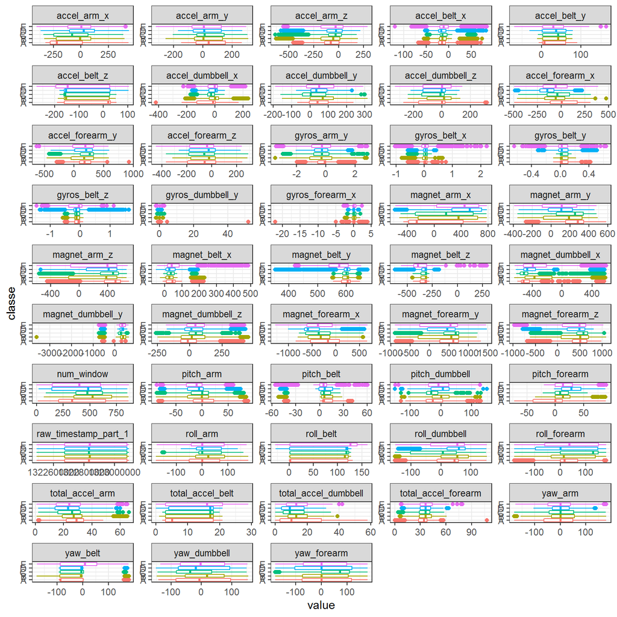

```r
ggplot(data = dat_full5, aes(x = classe, y = value, col = classe))+

  geom_boxplot(show.legend = F)+

  facet_wrap(~variable, scales = "free", ncol = 5)+

  theme(strip.text.x = element_text(size = 8))+

  coord_flip() + theme_bw()
```

# Split the training data randomly to train and test data

```r
set.seed(123)

split_data<-createDataPartition(y=dat_full4$classe, p= 0.75, list = F)

train_data<-dat_full4[split_data,]

val_data<-dat_full4[-split_data,]

dim(train_data)
```

```
## [1] 14718    49
```

```r
dim(val_data)
```

```
## [1] 4904   49
```

The train data composed of 14,718 rows and test data (val_data) composed of 4,904 rows.

### Scaling all columns

```r
# read original testing data

dat_test<-read.csv("D:/R/coursera/machinelearning/pml-testing.csv")

names(dat_test)
```

```
##   [1] "X"                        "user_name"
##   [3] "raw_timestamp_part_1"     "raw_timestamp_part_2"
##   [5] "cvtd_timestamp"           "new_window"
##   [7] "num_window"               "roll_belt"
##   [9] "pitch_belt"               "yaw_belt"
##  [11] "total_accel_belt"         "kurtosis_roll_belt"
##  [13] "kurtosis_picth_belt"      "kurtosis_yaw_belt"
##  [15] "skewness_roll_belt"       "skewness_roll_belt.1"
##  [17] "skewness_yaw_belt"        "max_roll_belt"
##  [19] "max_picth_belt"           "max_yaw_belt"
##  [21] "min_roll_belt"            "min_pitch_belt"
##  [23] "min_yaw_belt"             "amplitude_roll_belt"
##  [25] "amplitude_pitch_belt"     "amplitude_yaw_belt"
##  [27] "var_total_accel_belt"     "avg_roll_belt"
##  [29] "stddev_roll_belt"         "var_roll_belt"
```

[output cut: 65 more lines]

```r
# select important columns

dat_test2<-dat_test %>% dplyr::select(all_of(names(dat_full4)[-49]))

sum(is.na(dat_test2))
```

```
## [1] 0
```

```r
pre<-preProcess(train_data[,-49], method = c("center", "scale"))

dat_train<-predict(pre,train_data)

dat_train %>% get_summary_stats(type = "mean_sd")
```

```
## # A tibble: 48 x 4
##    variable             n  mean    sd
##    <chr>            <dbl> <dbl> <dbl>
##  1 accel_arm_x      14718     0     1
##  2 accel_arm_y      14718     0     1
##  3 accel_arm_z      14718     0     1
##  4 accel_belt_x     14718     0     1
##  5 accel_belt_y     14718     0     1
##  6 accel_belt_z     14718     0     1
##  7 accel_dumbbell_x 14718     0     1
##  8 accel_dumbbell_y 14718     0     1
##  9 accel_dumbbell_z 14718     0     1
## 10 accel_forearm_x  14718     0     1
## # ... with 38 more rows
```

```r
dat_val<-predict(pre,val_data)

dat_val %>% get_summary_stats(type = "mean_sd")
```

```
## # A tibble: 48 x 4
##    variable             n   mean    sd
##    <chr>            <dbl>  <dbl> <dbl>
##  1 accel_arm_x       4904  0.007 0.986
##  2 accel_arm_y       4904  0.015 0.998
##  3 accel_arm_z       4904 -0.003 1.01
##  4 accel_belt_x      4904 -0.004 0.996
##  5 accel_belt_y      4904 -0.013 1.00
##  6 accel_belt_z      4904  0.011 1.00
##  7 accel_dumbbell_x  4904 -0.011 0.99
##  8 accel_dumbbell_y  4904 -0.005 0.997
##  9 accel_dumbbell_z  4904 -0.01  0.999
## 10 accel_forearm_x   4904  0.014 1.00
## # ... with 38 more rows
```

```r
dat_test3<-predict(pre, dat_test2)

dat_test3 %>% get_summary_stats(type = "mean_sd")
```

```
## # A tibble: 48 x 4
##    variable             n   mean    sd
##    <chr>            <dbl>  <dbl> <dbl>
##  1 accel_arm_x         20 -0.405 0.83
##  2 accel_arm_y         20  0.645 0.844
##  3 accel_arm_z         20 -0.124 0.817
##  4 accel_belt_x        20 -0.267 0.667
##  5 accel_belt_y        20 -0.416 0.98
##  6 accel_belt_z        20  0.551 0.904
##  7 accel_dumbbell_x    20 -0.284 1.38
##  8 accel_dumbbell_y    20  0.221 0.916
##  9 accel_dumbbell_z    20 -0.201 1.19
## 10 accel_forearm_x     20  0.56  0.87
## # ... with 38 more rows
```

To avoid overfitting of random forest, we use the cross-validation to control the model building.

We create 10 different folds. VerboseIter argument tracks the progress of model building.

```r
library(randomForest)

set.seed(123)

mod_rf<-train(classe~., method="rf", data = dat_train,

              trControl = trainControl(method = "cv",

                                       number = 10, verboseIter = T))
mod_rf
```

```
## Random Forest
##
## 14718 samples
##    48 predictor
##     5 classes: 'A', 'B', 'C', 'D', 'E'
##
## No pre-processing
## Resampling: Cross-Validated (10 fold)
## Summary of sample sizes: 13247, 13247, 13247, 13246, 13245, 13247, ...
## Resampling results across tuning parameters:
##
##   mtry  Accuracy   Kappa
##    2    0.9965346  0.9956166
##   25    0.9987771  0.9984532
##   48    0.9981656  0.9976798
##
## Accuracy was used to select the optimal model using the largest value.
## The final value used for the model was mtry = 25.
```

The model produced very high accuracy on the training part of the training data = 0.998.

#### Confusion matrix

```r
dat_val$classe<-factor(dat_val$classe)

pred_test<- predict(mod_rf, dat_val)

confusionMatrix(data = pred_test, reference = dat_val$classe)
```

```
## Confusion Matrix and Statistics
##
##           Reference
## Prediction    A    B    C    D    E
##          A 1395    0    0    0    0
##          B    0  949    3    0    0
##          C    0    0  852    0    0
##          D    0    0    0  804    0
##          E    0    0    0    0  901
##
## Overall Statistics
##
##                Accuracy : 0.9994
##                  95% CI : (0.9982, 0.9999)
##     No Information Rate : 0.2845
##     P-Value [Acc > NIR] : < 2.2e-16
##
##                   Kappa : 0.9992
##
##  Mcnemar's Test P-Value : NA
##
## Statistics by Class:
##
##                      Class: A Class: B Class: C Class: D Class: E
## Sensitivity            1.0000   1.0000   0.9965   1.0000   1.0000
## Specificity            1.0000   0.9992   1.0000   1.0000   1.0000
## Pos Pred Value         1.0000   0.9968   1.0000   1.0000   1.0000
## Neg Pred Value         1.0000   1.0000   0.9993   1.0000   1.0000
## Prevalence             0.2845   0.1935   0.1743   0.1639   0.1837
## Detection Rate         0.2845   0.1935   0.1737   0.1639   0.1837
## Detection Prevalence   0.2845   0.1941   0.1737   0.1639   0.1837
## Balanced Accuracy      1.0000   0.9996   0.9982   1.0000   1.0000
```

```r
#pred_test_20<- predict(mod_rf, dat_test3)

#pred_test_20
```

The expected out of sample error is nearly zero for the test data that is part of the train data.